# FinalScript

Gabriela Merino

5/19/2020

## Analyzing MTC data

This file contains all the processing performed for analyzing MTC data in order to compare values observed using different prosthesis and under several use conditions.

```r
library(dplyr)
library(ggplot2)
library(cowplot)
library(nlme)
library(emmeans)
```

### Data loading and formatting

Data is stored as a ‘.csv’ file. Contained columns are:

- MTC: Measured MTC value
- Persona: ID of the patient
- Protesis: Prosthesis used for the measurement. It could be
  - 1 (‘Mech’ or ‘NAA’)
  - 2 (‘Echelon’ or ‘AHA’)
  - 3 (‘Elan’ or ‘AHA-MC’)
- Rampa: Indicates if the MTC was measured in ascent (1) or descent (2) walk ramp
- Prot..Hab: Prosthesis the patient uses daily. It could be
  - 1 (‘Mech’ or ‘NAA’)
  - 2 (‘Echelon’ or ‘AHA’)
  - 3 (‘Elan’ or ‘AHA’)
- Lado: Refers to the arm-side measured (1: ‘Amputee’, 2: ‘Sound’)

```r
MTCData<-read.csv("Gaby_V2.csv",  header=T)
head(MTCData)
```

```
##        MTC Persona Protesis Rampa Prot..Habitual Lado
## 1 48.87205       1        1     2              2    1
## 2 31.58478       1        1     2              2    1
## 3 55.19901       1        1     2              2    1
## 4 36.69334       1        1     2              2    1
## 5 56.62709       1        1     2              2    1
## 6 39.07622       1        1     2              2    1
```

```r
names(MTCData)[2:6]<-c("Patient", "Prosthesis", "Terrain",
                       "Habitual prosthesis", "Side")

for(i in 2:ncol(MTCData))
{MTCData[,i]<-factor(MTCData[,i])}

levels(MTCData$Prosthesis)<-c("NAA", "AHA", "AHA-MC")
levels(MTCData[,"Habitual prosthesis"])<-c("NAA", "AHA", "AHA")
levels(MTCData$Terrain)<-c("Ascent", "Descent")
levels(MTCData$Side)<-c("Amputee", "Sound")
```

### Data exploration

```r
summary(MTCData)
```

```
##       MTC            Patient      Prosthesis     Terrain     Habitual prosthesis      Side
##  Min.   :  1.21   2      : 260   NAA   :723   Ascent :1171   NAA:1038            Amputee:1120
##  1st Qu.: 14.84   10     : 211   AHA   :770   Descent:1088   AHA:1221            Sound  :1139
##  Median : 20.38   8      : 201   AHA-MC:766
##  Mean   : 21.65   4      : 191
##  3rd Qu.: 27.23   1      : 187
##  Max.   :103.65   3      : 182
##                   (Other):1027
```

```r
quantile(MTCData$MTC,probs = 0.99)
```

```
##      99%
## 48.91263
```

Filtering MTC data considering the 99% quantile as a threshold.

```r
MTCData%>%
  filter(MTC < quantile(MTCData$MTC,probs = 0.99)) -> redData

MTCData%>%
  filter(MTC >= quantile(MTCData$MTC,probs = 0.99)) -> filteredData
```

Looking the filtered data

```r
table(filteredData$Prosthesis,filteredData$Patient)
```

```
##
##          1 2 3 4 5 6 7 8 9 10 11 12 13
##   NAA    4 0 0 0 0 0 0 0 0  0  0  0  0
##   AHA    9 0 0 1 0 0 2 0 0  0  0  0  0
##   AHA-MC 3 0 0 1 0 0 2 0 0  1  0  0  0
```

```r
table(filteredData[,"Habitual prosthesis"],filteredData$Patient)
```

```
##
##        1  2  3  4  5  6  7  8  9 10 11 12 13
##   NAA  0  0  0  0  0  0  0  0  0  1  0  0  0
##   AHA 16  0  0  2  0  0  4  0  0  0  0  0  0
```

```r
table(filteredData$Terrain,filteredData$Patient)
```

```
##
##            1  2  3  4  5  6  7  8  9 10 11 12 13
##   Ascent   2  0  0  0  0  0  2  0  0  0  0  0  0
##   Descent 14  0  0  2  0  0  2  0  0  1  0  0  0
```

```r
table(filteredData$Side,filteredData$Patient)
```

```
##
##            1  2  3  4  5  6  7  8  9 10 11 12 13
##   Amputee 14  0  0  0  0  0  3  0  0  0  0  0  0
##   Sound    2  0  0  2  0  0  1  0  0  1  0  0  0
```

Summary of the data kept for the analysis

```r
summary(redData)
```

```
##       MTC           Patient      Prosthesis     Terrain     Habitual prosthesis      Side
##  Min.   : 1.21   2      : 260   NAA   :719   Ascent :1167   NAA:1037            Amputee:1103
##  1st Qu.:14.79   10     : 210   AHA   :758   Descent:1069   AHA:1199            Sound  :1133
##  Median :20.23   8      : 201   AHA-MC:759
##  Mean   :21.29   4      : 189
##  3rd Qu.:26.93   3      : 182
##  Max.   :48.87   1      : 171
##                  (Other):1023
```

```r
summary(redData$Patient)
```

```
##   1   2   3   4   5   6   7   8   9  10  11  12  13
## 171 260 182 189 165 123 157 201 150 210 140 154 134
```

Exploring the MTC density plot before and after filtering.

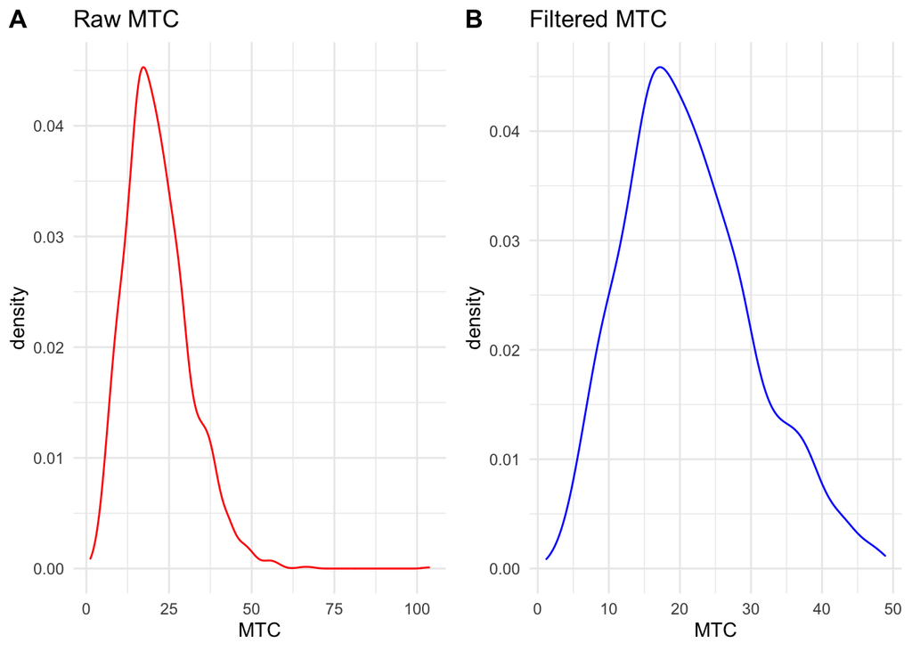

```r
g<-ggplot(MTCData, aes(x=MTC))+geom_density(color="red")+
  labs(title="Raw MTC")+theme_minimal()
gf<-ggplot(redData, aes(x=MTC))+geom_density(color="blue")+
  labs(title="Filtered MTC")+theme_minimal()

p<-plot_grid(g,gf,labels=c("A", "B"))
p
```

```r
ggplot2::ggsave(p, file="densityMTC.png", height=5, width=7, dpi=450)
```

#### Exploring MTC of amputee sides

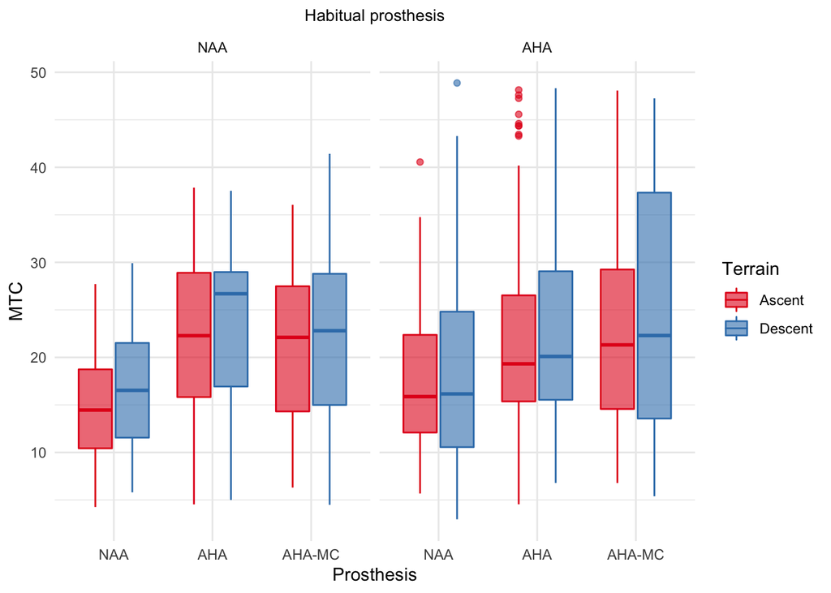

```r
redDataAmp<-redData[redData$Side=="Amputee",]
g<-ggplot(redDataAmp, aes(x=Prosthesis, y=MTC,
   fill=Terrain,color=Terrain))+geom_boxplot(alpha=0.6)+facet_grid(~get(
   'Habitual prosthesis'))+ labs(title="Habitual prosthesis")+theme_minimal()+
   scale_fill_brewer(palette = "Set1")+scale_color_brewer(palette = "Set1")+
   theme(plot.title=element_text(size=10, hjust = 0.5))
g
```

```r
ggsave(g, file="BoxplotMTC.png", width=8.5, height=6, dpi=600)
```

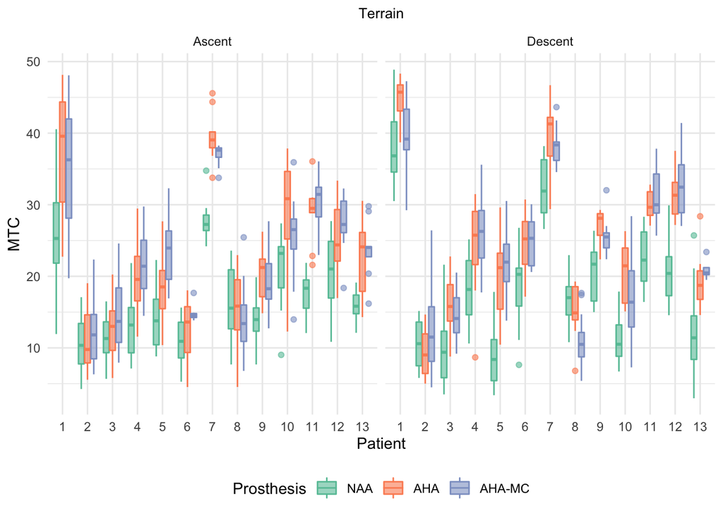

```r
g<-ggplot(redDataAmp, aes(x=Patient, y=MTC,
    fill=Prosthesis, color=Prosthesis))+geom_boxplot(alpha=0.6)+
    facet_grid(~Terrain)+ labs(title="Terrain")+theme_minimal()+
    scale_fill_brewer(palette = "Set2")+scale_color_brewer(palette = "Set2")+
    theme(plot.title=element_text(size=10, hjust = 0.5),
    legend.position = "bottom")
g
```

```r
ggsave(g, file="BoxplotMTCPersona.png", width=8, height=6, dpi=600)
```

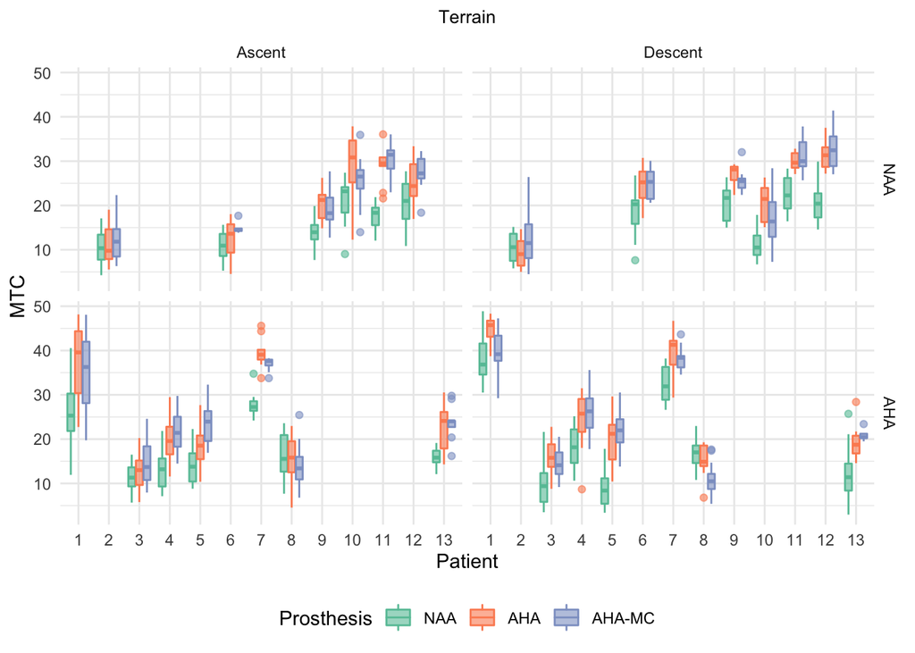

```r
g<-g+facet_grid(get('Habitual prosthesis')~Terrain)
g
```

```r
ggsave(g, file="BoxplotMTCPersona2.png", width=8, height=6, dpi=600)
```

#### Exploring MTC of sound sides

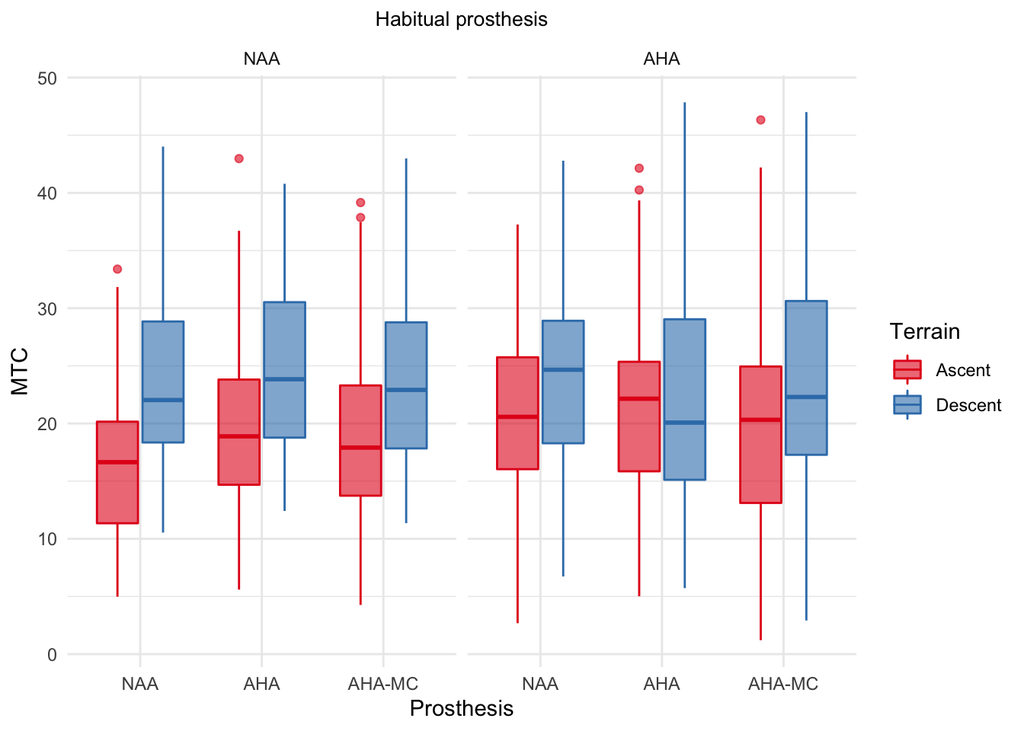

```r
redDataSound<-redData[redData$Side=="Sound",]
g<-ggplot(redDataSound, aes(x=Prosthesis, y=MTC,
    fill=Terrain, color=Terrain))+geom_boxplot(alpha=0.6)+
    facet_grid(~get('Habitual prosthesis'))+
    labs(title="Habitual prosthesis")+theme_minimal()+
    scale_fill_brewer(palette = "Set1")+scale_color_brewer(palette = "Set1")+
    theme(plot.title=element_text(size=10, hjust = 0.5))
g
```

```r
ggsave(g, file="BoxplotMTCSano.png", width=8, height=6, dpi=600)
```

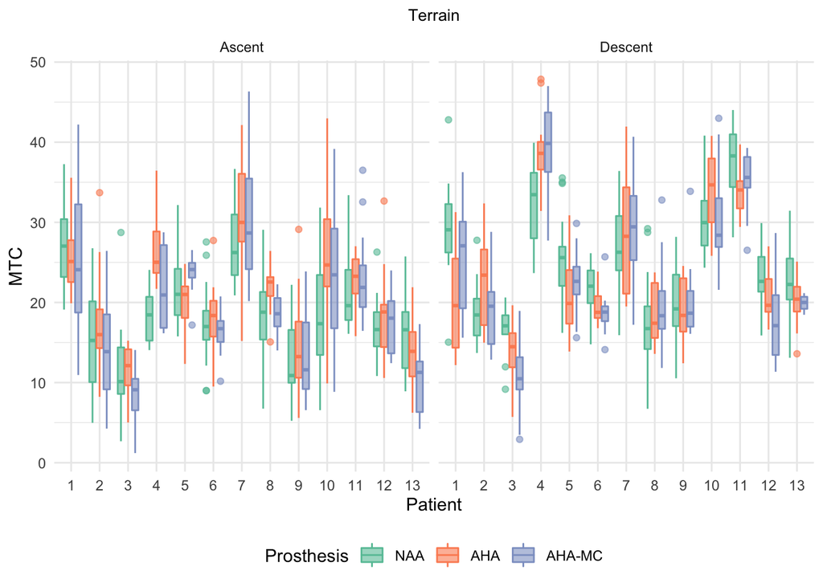

```r
g<-ggplot(redData[redData$Side=="Sound",], aes(x=Patient, y=MTC, fill=Prosthesis,
    color=Prosthesis))+geom_boxplot(alpha=0.6)+facet_grid(~Terrain)+ labs(
    title="Terrain")+theme_minimal()+scale_fill_brewer(palette = "Set2")+
    scale_color_brewer(palette = "Set2")+theme(plot.title=element_text(size=10,
    hjust = 0.5), legend.position = "bottom")
g
```

```r
ggsave(g, file="BoxplotMTCPersonaSano.png", width=8, height=6, dpi=600)
```

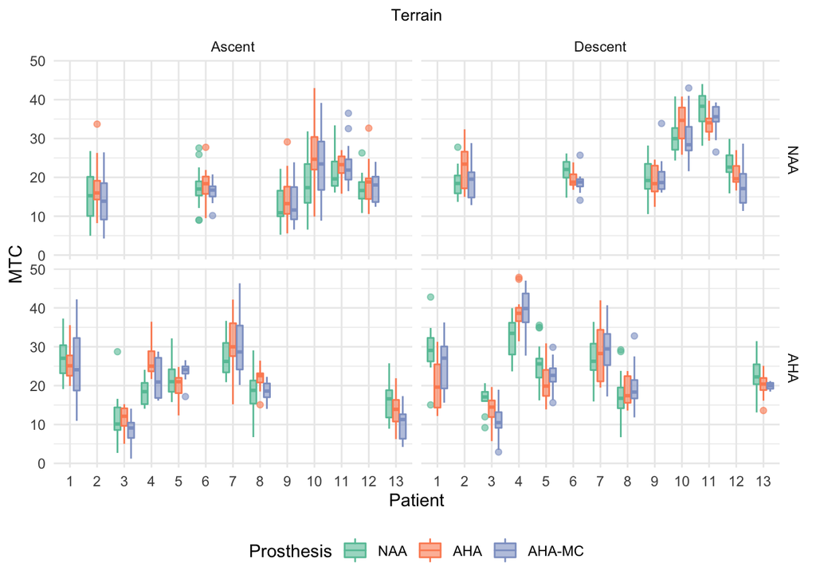

```r
g<-g+facet_grid(get('Habitual prosthesis')~Terrain)
g
```

```r
ggsave(g, file="BoxplotMTCPersonaSano2.png", width=8, height=6, dpi=600)
```

### MTC model

We will follow the Top-Down strategy, propossing, as a first step, a maximal model for the fixed effects and the right structure for random variables.

```r
# only for lme using
names(redDataAmp)[5]<-paste(strsplit(names(redDataAmp)[5],split=" ")[[1]], collapse="_")
```

For the fixed effect components, we are interested in evaluating changes in the MTC due to the use of different prosthesis within each terrain without comparison between them. We also want to evaluate possible effects of the habitual use of a specific prosthesis.

Starting with a single structure for random effects:

```r
MTCModel<-lme(MTC~Terrain+Habitual_prosthesis+Terrain:Habitual_prosthesis+Habitual_prosthesis:Prosthesis+Habitual_prosthesis:Terrain:Prosthesis, random=~1|Patient,method="REML",
data=redDataAmp, control = list(opt = "optim"))
anova(MTCModel)
```

```
##                                        numDF denDF  F-value p-value
## (Intercept)                                1  1080 92.40795  <.0001
## Terrain                                    1  1080 10.05585  0.0016
## Habitual_prosthesis                        1    11  0.15714  0.6994
## Terrain:Habitual_prosthesis                1  1080  0.15114  0.6975
## Habitual_prosthesis:Prosthesis             4  1080 57.67841  <.0001
## Terrain:Habitual_prosthesis:Prosthesis     4  1080  0.94983  0.4343
```

Another structure for the random effects:

```r
MTCModelRE<-lme(MTC~Terrain+Habitual_prosthesis+Terrain:Habitual_prosthesis+Habitual_prosthesis:Prosthesis+Habitual_prosthesis:Terrain:Prosthesis, random=~Habitual_prosthesis-1|Patient,method="REML",
data=redDataAmp, control = list(opt = "optim"))
anova(MTCModelRE)
```

```
##                                        numDF denDF   F-value p-value
## (Intercept)                                1  1080 118.30557  <.0001
## Terrain                                    1  1080  10.06934  0.0016
## Habitual_prosthesis                        1    11   0.17148  0.6868
## Terrain:Habitual_prosthesis                1  1080   0.14819  0.7003
## Habitual_prosthesis:Prosthesis             4  1080  57.72264  <.0001
## Terrain:Habitual_prosthesis:Prosthesis     4  1080   0.94975  0.4343
```

For choosing the right model for the random effects we should perform LRT tests between nested models.

LRT test between `MTCModel` and `MTCModelRE`:

```r
anova(MTCModelRE, MTCModel)
```

```
##            Model df      AIC      BIC    logLik   Test  L.Ratio p-value
## MTCModelRE     1 16 6954.347 7034.265 -3461.174
## MTCModel       2 14 6951.857 7021.785 -3461.928 1 vs 2 1.509187  0.4702
```

The p-value is not significant, at a significance level (=0.05), MTCModel is preferred (the simplest one).

```r
anova(MTCModel)
```

```
##                                        numDF denDF  F-value p-value
## (Intercept)                                1  1080 92.40795  <.0001
## Terrain                                    1  1080 10.05585  0.0016
## Habitual_prosthesis                        1    11  0.15714  0.6994
## Terrain:Habitual_prosthesis                1  1080  0.15114  0.6975
## Habitual_prosthesis:Prosthesis             4  1080 57.67841  <.0001
## Terrain:Habitual_prosthesis:Prosthesis     4  1080  0.94983  0.4343
```

Now, we must to choose the structure of the residuals covariance matrix

```r
MTCModelCorRes<-lme(MTC~Terrain+Habitual_prosthesis+Terrain:Habitual_prosthesis+Habitual_prosthesis:Prosthesis+Habitual_prosthesis:Terrain:Prosthesis,    random=~1|Patient,method="REML",
data=redDataAmp, control = list(opt = "optim"), weights=varIdent(form=~1|Habitual_prosthesis))
anova(MTCModelCorRes, MTCModel)
```

```
##                Model df      AIC      BIC    logLik   Test   L.Ratio p-value
## MTCModelCorRes     1 15 6953.556 7028.479 -3461.778
## MTCModel           2 14 6951.857 7021.785 -3461.928 1 vs 2 0.3007962  0.5834
```

The p-value too large, at a significance level (=0.05), we prefer the model without structure for the covariance matrix of the residuals.

Now, we must to reduce the fixed effects removing those that are not significant. In order to perform a LRT for comparing the fixed effect structure of nested models, they should be fitted using ML.

```r
MTCModelREML<-lme(MTC~Terrain+Habitual_prosthesis+Terrain:Habitual_prosthesis+Habitual_prosthesis:Prosthesis+Terrain:Habitual_prosthesis:Prosthesis,    random=~1|Patient,method="ML",
data=redDataAmp, control = list(opt = "optim"))
```

```r
anova(MTCModelREML)
```

```
##                                        numDF denDF   F-value p-value
## (Intercept)                                1  1080 108.02099  <.0001
## Terrain                                    1  1080  10.04331  0.0016
## Habitual_prosthesis                        1    11   0.18363  0.6765
## Terrain:Habitual_prosthesis                1  1080   0.15078  0.6979
## Habitual_prosthesis:Prosthesis             4  1080  57.57985  <.0001
## Terrain:Habitual_prosthesis:Prosthesis     4  1080   0.94645  0.4362
```

```r
MTCModelRERedML<-lme(MTC~Terrain+Habitual_prosthesis+Habitual_prosthesis:Prosthesis, random=~1|Patient,method="ML",
data=redDataAmp, control = list(opt = "optim"))
```

And the p-value of the LRT for these two models is,

```r
stat<- (-2*logLik(MTCModelRERedML, REML=FALSE)+2*logLik(MTCModelREML, REML=FALSE))[1]
stat
```

```
## [1] 4.304966
```

```r
pval<-pchisq(stat,df=5,lower.tail=FALSE)
pval
```

```
## [1] 0.5063943
```

Thus, the simplest one model (‘MTCModelRERedML’) is preffered.

```r
anova(MTCModelRERedML)
```

```
##                                numDF denDF   F-value p-value
## (Intercept)                        1  1085 108.94777  <.0001
## Terrain                            1  1085  10.04935  0.0016
## Habitual_prosthesis                1    11   0.18521  0.6752
## Habitual_prosthesis:Prosthesis     4  1085  57.53043  <.0001
```

##### Model evaluation

The final model is:

```r
FinalModel<-lme(MTC~Terrain+Habitual_prosthesis+Habitual_prosthesis:Prosthesis, random=~1|Patient,method="REML", data=redDataAmp, control = list(opt = "optim"))
```

We should perform some diagnostics tests for proving the model assumptions are being met.

As a first step, we should explore the EBLUPs. They must have mean equal to zero and be normally distributed. We will use graphical and analytical tools for exploring these features.

```r
EBLUPs<-ranef(FinalModel)
apply(EBLUPs,2, shapiro.test)
```

```
## $`(Intercept)`
##
##  Shapiro-Wilk normality test
##
## data:  newX[, i]
## W = 0.91028, p-value = 0.185
```

The null hypothesis of the Shapiro-Wilk test is that the sample belongs from a normal distribution. Thus, given a p-value of 0.185 we cannot reject H0.

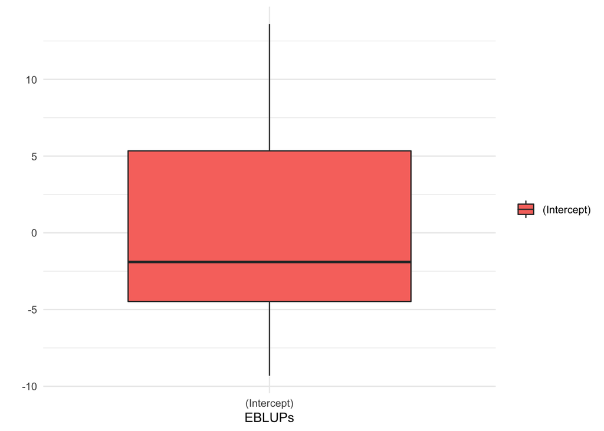

```r
g<-ggplot(reshape2::melt(EBLUPs), aes(x=variable, y=value, fill=variable))+
  geom_boxplot()+theme(legend.position = "None")+theme_minimal()+labs(x="EBLUPs",y="",fill="")
g
```

```r
ggsave(g,file="boxplotEBLUPsAmp.jpeg", width = 7, height = 5)
```

The model residuals must be explored too. We will consider Pearson residuals for both, the QQ-plot and the scatter plot of predicted/residuals values.

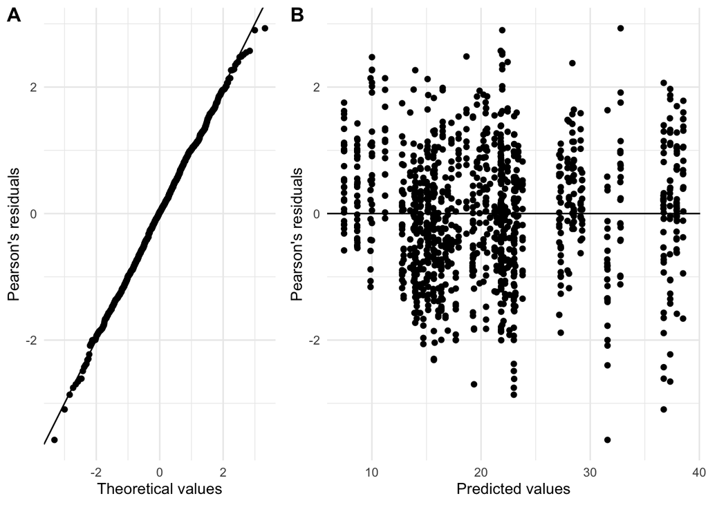

```r
PearsonRes<-resid(FinalModel, type="pearson")
fittedValues<-predict(FinalModel)
df<-data.frame(redDataAmp,PearsonRes, fittedValues)
a<-ggplot(df, aes(sample=PearsonRes))+geom_qq()+geom_abline(slope=1, intercept=0)+labs(y="Pearson's residuals", x="Theoretical values")+theme(legend.position = "none")+theme_minimal()
b<-ggplot(df, aes(x=fittedValues,y=PearsonRes))+geom_point()+geom_hline(yintercept = 0)+labs(y="Pearson's residuals", x="Predicted values")+theme_minimal()
g<-plot_grid(a,b, nrow=1, labels=c("A", "B"), rel_widths = c(0.8, 1.2))
g
```

```r
ggplot2::ggsave(g, file="ResidAmp.jpeg", width = 7, height = 5, unit="in", dpi=500)
```

We can also check the independence between residuals and independent variables.

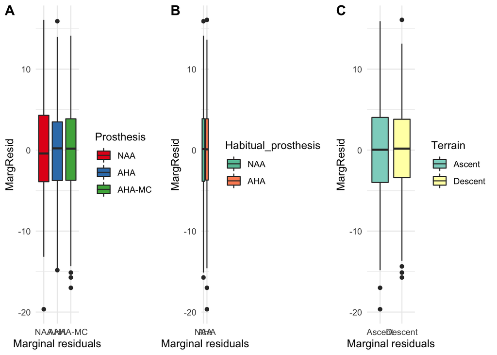

```r
df$MargResid<-resid(FinalModel, type="response")
a<-ggplot(df, aes(y=MargResid,x=Prosthesis, fill=Prosthesis))+
  geom_boxplot()+labs(x="Marginal residuals")+theme_minimal()+
  scale_fill_brewer(palette = "Set1")
b<-ggplot(df, aes(y=MargResid,x=Habitual_prosthesis, fill=Habitual_prosthesis))+
  geom_boxplot()+labs(x="Marginal residuals")+theme_minimal()+
  scale_fill_brewer(palette = "Set2")
d<-ggplot(df, aes(y=MargResid,x=Terrain, fill=Terrain))+geom_boxplot()+
  labs(x="Marginal residuals")+theme_minimal()+
  scale_fill_brewer(palette = "Set3")
plot_grid(a,b,d, nrow=1, labels=c("A", "B", "C"))
```

#### Analyzing model results

The equation defining our model is
$$\begin{equation}
MTC_{ijkl}=\mu_0+u_{i}+\alpha_j+\beta_k+\delta_{jl}+\epsilon_{ijkl},~ with~\epsilon_{ijkl}\sim N(0,\sigma^2),~and~u_{i}\sim N(0,\sigma_u^2)
\end{equation}$$

where:

- $u_{i}$ is the random effect realted to the *i-th* patient,
- $\alpha_j$ is the effect of the *j-th* level of the Terrain variable,
- $\beta_k$ is the effect of the *k-th* level of the Habitual prosthesis variable,
- $\delta_jl$ is the effect of the *l-th* level of the Prosthesis variable for individuals using the *j-th* Habitual prosthesis

Exploring the value and significance of the model coefficient derived from these effects:

```r
summary(FinalModel)
```

```
## Linear mixed-effects model fit by REML
##  Data: redDataAmp
##        AIC      BIC   logLik
##   6955.101 7000.096 -3468.55
##
## Random effects:
##  Formula: ~1 | Patient
##         (Intercept) Residual
## StdDev:    8.057466 5.490612
##
## Fixed effects: MTC ~ Terrain + Habitual_prosthesis + Habitual_prosthesis:Prosthesis
##                                             Value Std.Error   DF   t-value p-value
## (Intercept)                             16.504315  3.321211 1085  4.969367  0.0000
## TerrainDescent                           1.201583  0.333246 1085  3.605688  0.0003
## Habitual_prosthesisAHA                   1.480550  4.521958   11  0.327413  0.7495
## Habitual_prosthesisNAA:ProsthesisAHA     5.456229  0.613763 1085  8.889793  0.0000
## Habitual_prosthesisAHA:ProsthesisAHA     5.744912  0.557029 1085 10.313487  0.0000
## Habitual_prosthesisNAA:ProsthesisAHA-MC  5.316988  0.595019 1085  8.935834  0.0000
## Habitual_prosthesisAHA:ProsthesisAHA-MC  5.149450  0.570525 1085  9.025807  0.0000
##  Correlation:
##                                         (Intr) TrrnDs Hb_AHA Hb_NAA:PAHA Hb_AHA:PAHA H_NAA:PAHA-
## TerrainDescent                          -0.052
## Habitual_prosthesisAHA                  -0.732  0.000
## Habitual_prosthesisNAA:ProsthesisAHA    -0.088  0.020  0.064
## Habitual_prosthesisAHA:ProsthesisAHA    -0.002  0.045 -0.068  0.001
## Habitual_prosthesisNAA:ProsthesisAHA-MC -0.088 -0.012  0.065  0.481      -0.001
## Habitual_prosthesisAHA:ProsthesisAHA-MC  0.000  0.010 -0.066  0.000       0.539       0.000
##
## Standardized Within-Group Residuals:
##         Min          Q1         Med          Q3         Max
## -3.57889233 -0.69352711  0.01747167  0.70571607  2.92982087
##
## Number of Observations: 1103
## Number of Groups: 13
```

As can be observed, excepting the coefficient related to the effect of the Habitual prosthesis variable, all the model coefficients have associated a small p-value enough to reject the null hypothesis of individual tests of coefficient nullity.

We can also compute the intra-class correlation coefficient (ICC) for measuring the percentage of model variance that is explained for the random effect (Patient).

```r
VarCorr(FinalModel)
```

```
## Patient = pdLogChol(1)
##             Variance StdDev
## (Intercept) 64.92276 8.057466
## Residual    30.14682 5.490612
```

```r
ICC=round(as.numeric(VarCorr(FinalModel)[1,1])/sum(as.numeric(VarCorr(FinalModel)[,1]))*100,3)
ICC
```

```
## [1] 68.29
```

Thus, 68% of the data variability is due to the variability between patients.

Since we are interested in comparing the MTC among different experimental conditions, we will use the Tukey procedure as a post-hoc test.

Our model has two significant effects:

- Terrain: The average MTC observed in patients walking in ascent terrain is different from the one measured in descent terrain.
- Habitual Prosthesis*Prosthesis: The average MTC measured in patients using two different prostheses is different, for at least one combination of the levels of Prosthesis and for at least one level of the habitual prosthesis effect.

In order to identify those differences, we should obtain the estimated means per each combination of the model parameters and then perform the desired contrasts.

```r
emm<-emmeans(FinalModel, specs = ~ Terrain + Habitual_prosthesis + Habitual_prosthesis:Prosthesis,nesting = "Prosthesis %in% Habitual_prosthesis")
emm
```

```
##  Prosthesis Habitual_prosthesis Terrain emmean   SE df lower.CL upper.CL
##  NAA        NAA                 Ascent    16.5 3.32 12     9.27     23.7
##  AHA        NAA                 Ascent    22.0 3.32 12    14.72     29.2
##  AHA-MC     NAA                 Ascent    21.8 3.32 12    14.58     29.1
##  NAA        AHA                 Ascent    18.0 3.08 11    11.21     24.8
##  AHA        AHA                 Ascent    23.7 3.07 11    16.97     30.5
##  AHA-MC     AHA                 Ascent    23.1 3.08 11    16.37     29.9
##  NAA        NAA                 Descent   17.7 3.32 12    10.47     24.9
##  AHA        NAA                 Descent   23.2 3.32 12    15.92     30.4
##  AHA-MC     NAA                 Descent   23.0 3.32 12    15.79     30.3
##  NAA        AHA                 Descent   19.2 3.08 11    12.41     26.0
##  AHA        AHA                 Descent   24.9 3.07 11    18.17     31.7
##  AHA-MC     AHA                 Descent   24.3 3.08 11    17.57     31.1
##
## Degrees-of-freedom method: containment
## Confidence level used: 0.95
```

The table above displays MTC means per group. For instance, the estimated mean of MTC for patients daily using ‘NAA’ prostheses when are walking in an ascent terrain and using an ‘AHA’ prosthesis is 22 mm. Whereas, for the same patients the average MTC estimated in a descent terrain and also using an ‘AHA’ prosthesis is 23.2 mm.

The graphical comparisson for MTCs observed in different terrains is:

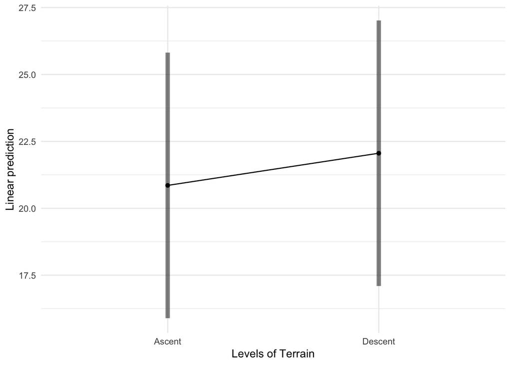

```r
g<-emmip(FinalModel, ~ Terrain, CIs = TRUE)+   theme(axis.text.x = element_text(angle =90))+theme_minimal()
g
```

```r
ggsave(g, file="emmeansAmpTerr.jpeg", height = 6, width=8)
```

The graphical comparisson for MTCs observed in different prosthesis for patients using the two habitual prosthesis here considered is:

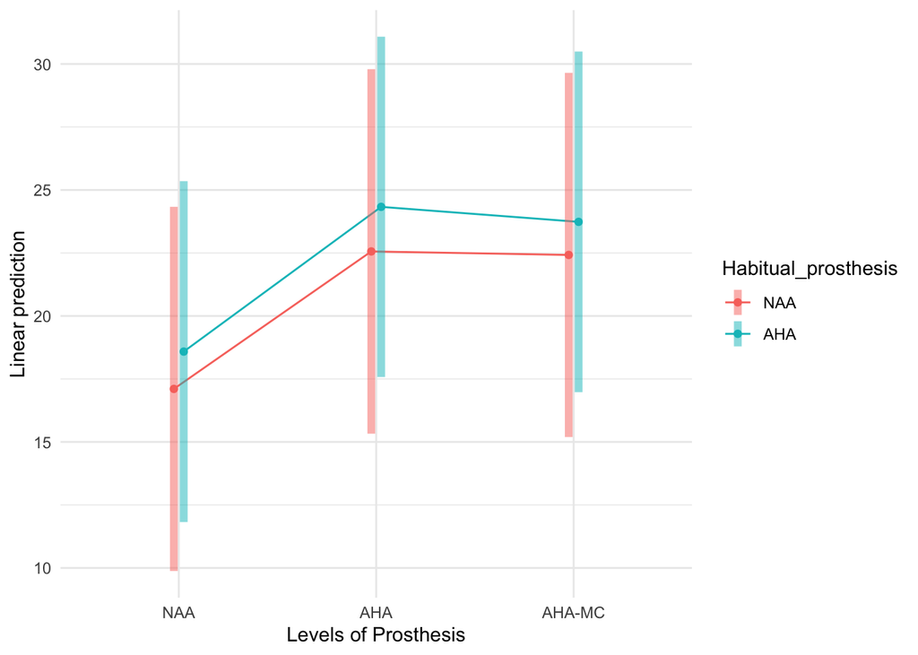

```r
g<-emmip(FinalModel, Habitual_prosthesis~Prosthesis, CIs = TRUE)+
    theme(axis.text.x = element_text(angle = 90))+theme_minimal()
g
```

The Tukey post-hoc test for the Terrain variable is:

```r
pairs(lsmeans(emm, ~ Terrain))
```

```
##  contrast         estimate    SE   df t.ratio p.value
##  Ascent - Descent     -1.2 0.333 1085 -3.606  0.0003
##
## Results are averaged over the levels of: Prosthesis, Habitual_prosthesis
## Degrees-of-freedom method: containment
```

Thus, on average, the MTC in descent terrain is higher than the MTC in ascent terrain in 1.2 units (mm)

The average values for MTC in the two terrains here considered are:

```r
lsmeans(emm, ~ Terrain)
```

```
##  Terrain lsmean   SE df lower.CL upper.CL
##  Ascent    20.9 2.25 11     15.9     25.8
##  Descent   22.1 2.25 11     17.1     27.0
##
## Results are averaged over the levels of: Prosthesis, Habitual_prosthesis
## Degrees-of-freedom method: containment
## Confidence level used: 0.95
```

The Tukey post-hoc test comparing Prosthesis in the two levels of Habitual prosthesis are:

```r
pairs(lsmeans(emm, ~Prosthesis|Habitual_prosthesis))
```

```
## Habitual_prosthesis = NAA:
##  contrast     estimate    SE   df t.ratio p.value
##  NAA - AHA      -5.456 0.614 1085  -8.890 <.0001
##  NAA - AHA-MC   -5.317 0.595 1085  -8.936 <.0001
##  AHA - AHA-MC    0.139 0.616 1085   0.226 0.9959
##
## Habitual_prosthesis = AHA:
##  contrast     estimate    SE   df t.ratio p.value
##  NAA - AHA      -5.745 0.557 1085 -10.313 <.0001
##  NAA - AHA-MC   -5.149 0.571 1085  -9.026 <.0001
##  AHA - AHA-MC    0.595 0.541 1085   1.100 0.6898
##
## Results are averaged over some or all of the levels of: Terrain
## Degrees-of-freedom method: containment
## P value adjustment: tukey method for comparing a family of 4 estimates
```

Thus, on average, the MTC for patients using prosthesis NAA is significantly lower than the MTC measured for both AHA and AHA-MC prostheses. This conclusion is valid for the two groups of patients defined by their habitual prosthesis.

The average values for MTC corresponding to the contrasts above are:

```r
lsmeans(emm, ~Prosthesis|Habitual_prosthesis)
```

```
## Habitual_prosthesis = NAA:
##  Prosthesis lsmean   SE df lower.CL upper.CL
##  NAA          17.1 3.32 12     9.88     24.3
##  AHA          22.6 3.32 12    15.33     29.8
##  AHA-MC       22.4 3.32 12    15.19     29.6
##
## Habitual_prosthesis = AHA:
##  Prosthesis lsmean   SE df lower.CL upper.CL
##  NAA          18.6 3.07 11    11.82     25.4
##  AHA          24.3 3.07 11    17.58     31.1
##  AHA-MC       23.7 3.07 11    16.98     30.5
##
## Results are averaged over the levels of: Terrain
## Degrees-of-freedom method: containment
## Confidence level used: 0.95
```

#### An alternative for the fixed components

An alternative model is considering all possible interactions between fixed effects, without considering blocking/nesting.

Another structure for the random effects:

```r
MTCModel2<-lme(MTC~Terrain*Habitual_prosthesis*Prosthesis, random=~1|Patient,method="REML",
data=redDataAmp, control = list(opt = "optim"))
anova(MTCModel2)
```

```
##                                        numDF denDF   F-value p-value
## (Intercept)                                1  1080  92.40795  <.0001
## Terrain                                    1  1080  10.05585  0.0016
## Habitual_prosthesis                        1    11   0.15714  0.6994
## Prosthesis                                 2  1080 115.03301  <.0001
## Terrain:Habitual_prosthesis                1  1080   0.44211  0.5062
## Terrain:Prosthesis                         2  1080   1.72565  0.1785
## Habitual_prosthesis:Prosthesis             2  1080   0.22023  0.8024
## Terrain:Habitual_prosthesis:Prosthesis     2  1080   0.13210  0.8763
```

An alternative structure for the random effects of this model is

```r
MTCModel2RE<-lme(MTC~Terrain*Habitual_prosthesis*Prosthesis, random=~Habitual_prosthesis-1|Patient,method="REML",
data=redDataAmp, control = list(opt = "optim"))
```

And the LRT test for comparing these two nested models is

```r
anova(MTCModel2RE,MTCModel2)
```

```
##             Model df      AIC      BIC    logLik   Test  L.Ratio p-value
## MTCModel2RE     1 16 6954.347 7034.265 -3461.174
## MTCModel2       2 14 6951.857 7021.785 -3461.928 1 vs 2 1.509187  0.4702
```

Or, considering a random effect over the Prosthesis:

```r
MTCModel2RE2<-lme(MTC~Terrain*Habitual_prosthesis*Prosthesis, random=~Prosthesis-1|Patient,method="REML",
data=redDataAmp, control = list(opt = "optim"))
```

And, the LRT is:

```r
anova(MTCModel2RE2,MTCModel2)
```

```
##              Model df      AIC      BIC    logLik   Test  L.Ratio p-value
## MTCModel2RE2     1 19 6850.860 6945.762 -3406.430
## MTCModel2        2 14 6951.857 7021.785 -3461.928 1 vs 2 110.9964  <.0001
```

In this case, the p-value is smaller than a significance threshold of 0.05, thus we prefer model ‘MTCModel2RE2’ over ‘MTCModel2’.

Analyzing alternatives ways for the structure of the covariance matrix of the model residuals,

```r
MTCModel2RE2CorRes<-lme(MTC~Terrain*Habitual_prosthesis*Prosthesis,    random=~Prosthesis-1|Patient,method="REML",
data=redDataAmp, control = list(opt = "optim"), weights=varIdent(form=~1|Habitual_prosthesis))
anova(MTCModel2RE2CorRes, MTCModel2RE2)
```

```
##                    Model df     AIC      BIC    logLik   Test    L.Ratio p-value
## MTCModel2RE2CorRes     1 20 6852.85 6952.747 -3406.425
## MTCModel2RE2           2 19 6850.86 6945.762 -3406.430 1 vs 2 0.01047751  0.9185
```

The p-value is to large, so we prefer do not have specific structures for the residuals covariance matrix.

Now, we should reduce the fixed effects in ‘MTCModel2RE2’.

```r
MTCModel2RE2ML<-lme(MTC~Terrain*Habitual_prosthesis*Prosthesis, random=~Prosthesis-1|Patient,method="ML",
data=redDataAmp, control = list(opt = "optim"))
anova(MTCModel2RE2ML)
```

```
##                                        numDF denDF  F-value p-value
## (Intercept)                                1  1080 92.34329  <.0001
## Terrain                                    1  1080 16.55947  0.0001
## Habitual_prosthesis                        1    11  0.08243  0.7794
## Prosthesis                                 2  1080 20.24543  <.0001
## Terrain:Habitual_prosthesis                1  1080  0.61585  0.4328
## Terrain:Prosthesis                         2  1080  2.45330  0.0865
## Habitual_prosthesis:Prosthesis             2  1080  0.07325  0.9294
## Terrain:Habitual_prosthesis:Prosthesis     2  1080  0.13840  0.8708
```

A reduced model is:

```r
MTCModel2RE2RedML<-lme(MTC~Terrain+Prosthesis, random=~Prosthesis-1|Patient,method="ML",
data=redDataAmp, control = list(opt = "optim"))
```

And the LRT test for comparing those models is

```r
stat<- (-2*logLik(MTCModel2RE2RedML, REML=FALSE)+2*logLik(MTCModel2RE2ML, REML=FALSE))[1]
stat
```

```
## [1] 6.086059
```

```r
pval<-pchisq(stat,df=8,lower.tail=FALSE)
pval
```

```
## [1] 0.6375925
```

The p-value is too large, so we prefer the simplest model ( ‘MTCModel2RE2RedML’).

```r
anova(MTCModel2RE2RedML)
```

```
##             numDF denDF  F-value p-value
## (Intercept)     1  1087 92.93318  <.0001
## Terrain         1  1087 16.58396  <.0001
## Prosthesis      2  1087 20.37123  <.0001
```

##### Model evaluation

The final model is:

```r
FinalModel<-lme(MTC~Terrain+Prosthesis, random=~Prosthesis-1|Patient,method="REML", data=redDataAmp, control = list(opt = "optim"))
```

We should perform some diagnostics tests for proving the model assumptions are being met.

As a first step, we should explore the EBLUPs. They must have mean equal to zero and be normally distributed. We will use graphical and analytical tools for exploring these features.

```r
EBLUPs<-ranef(FinalModel)
apply(EBLUPs,2, shapiro.test)
```

```
## $ProsthesisNAA
##
##  Shapiro-Wilk normality test
##
## data:  newX[, i]
## W = 0.86905, p-value = 0.0508
##
##
## $ProsthesisAHA
##
##  Shapiro-Wilk normality test
##
## data:  newX[, i]
## W = 0.924, p-value = 0.2839
##
##
## $`ProsthesisAHA-MC`
##
##  Shapiro-Wilk normality test
##
## data:  newX[, i]
## W = 0.92709, p-value = 0.312
```

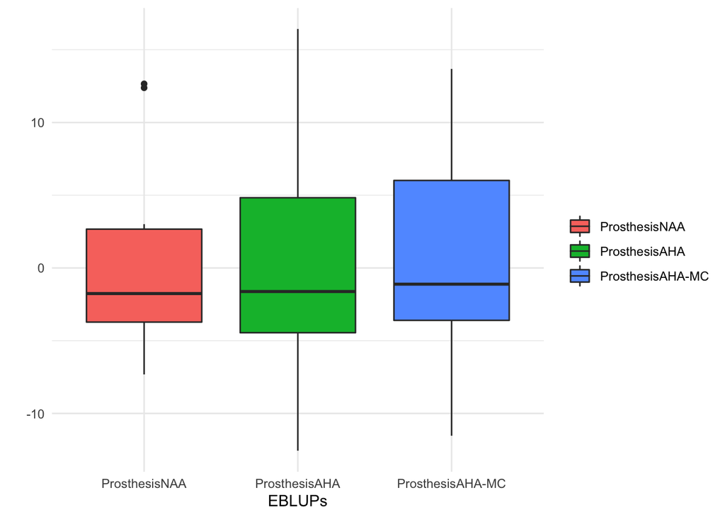

```r
g<-ggplot(reshape2::melt(EBLUPs), aes(x=variable, y=value, fill=variable))+
  geom_boxplot()+theme(legend.position = "None")+theme_minimal()+labs(x="EBLUPs",y="",fill="")
g
```

```r
ggsave(g,file="boxplotEBLUPsAmpModel2.jpeg", width = 7, height = 5)
```

In the previous plot, we can appreciate different variabilities for the MTC among the groups defined by the Prosthesis factor.

The model residuals must be explored too. We will consider Pearson residuals for both, the QQ-plot and the scatter plot of predicted/residuals values.

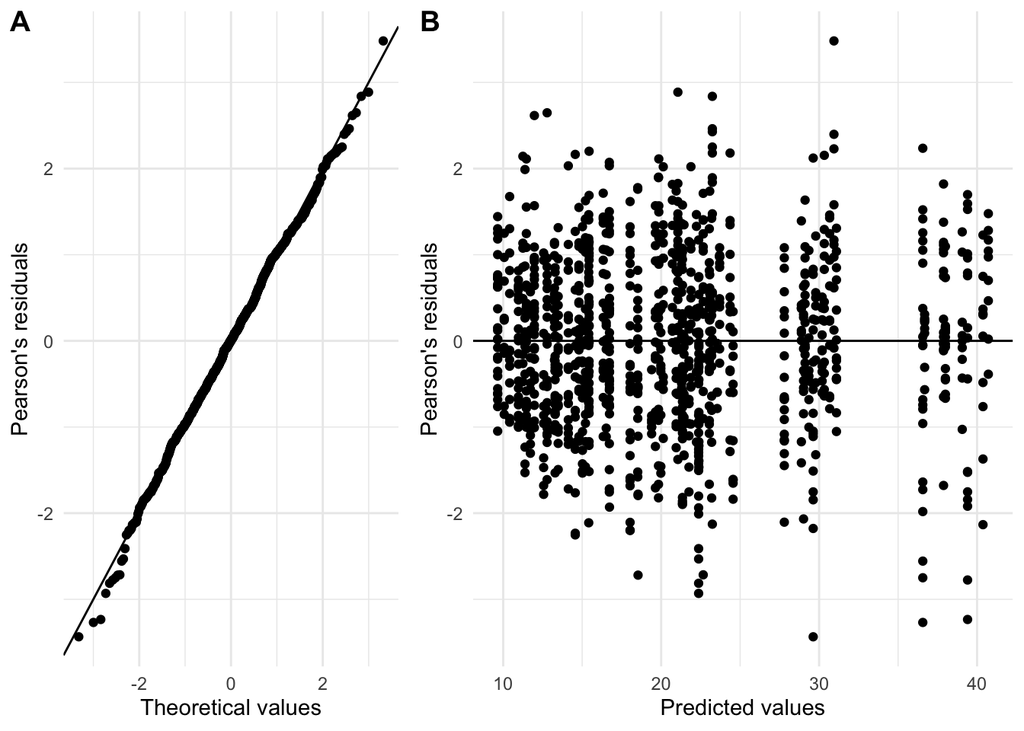

```r
PearsonRes<-resid(FinalModel, type="pearson")
fittedValues<-predict(FinalModel)
df<-data.frame(redDataAmp,PearsonRes, fittedValues)
a<-ggplot(df, aes(sample=PearsonRes))+geom_qq()+geom_abline(slope=1, intercept=0)+labs(y="Pearson's residuals", x="Theoretical values")+theme(legend.position = "none")+theme_minimal()
b<-ggplot(df, aes(x=fittedValues,y=PearsonRes))+geom_point()+geom_hline(yintercept = 0)+labs(y="Pearson's residuals", x="Predicted values")+theme_minimal()
g<-plot_grid(a,b, nrow=1, labels=c("A", "B"), rel_widths = c(0.8, 1.2))
g
```

```r
ggplot2::ggsave(g, file="ResidAmpModel2.jpeg", width = 7, height = 5, unit="in", dpi=500)
```

We can also check the independence between residuals and independent variables.

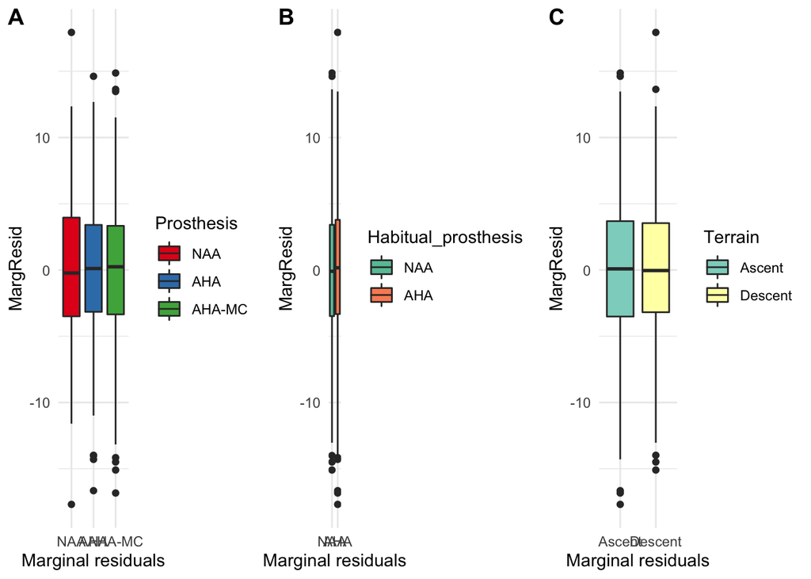

```r
df$MargResid<-resid(FinalModel, type="response")
a<-ggplot(df, aes(y=MargResid,x=Prosthesis, fill=Prosthesis))+
  geom_boxplot()+labs(x="Marginal residuals")+theme_minimal()+
  scale_fill_brewer(palette = "Set1")
b<-ggplot(df, aes(y=MargResid,x=Habitual_prosthesis, fill=Habitual_prosthesis))+
  geom_boxplot()+labs(x="Marginal residuals")+theme_minimal()+
  scale_fill_brewer(palette = "Set2")
d<-ggplot(df, aes(y=MargResid,x=Terrain, fill=Terrain))+geom_boxplot()+
  labs(x="Marginal residuals")+theme_minimal()+
  scale_fill_brewer(palette = "Set3")
plot_grid(a,b,d, nrow=1, labels=c("A", "B", "C"))
```

#### Analyzing model results

The equation defining our model is
$$\begin{equation}
MTC_{ijk}=\mu_0+u_{i}+\alpha_j+\beta_k+\epsilon_{ijk},~ with~\epsilon_{ijk}\sim N(0,\sigma^2),~and~u_{i}\sim N(0,\sigma_u^2)
\end{equation}$$

where:

- $u_{i}$ is the random effect realted to the *i-th* patient,
- $\alpha_j$ is the effect of the *j-th* level of the Terrain variable,
- $\beta_k$ is the effect of the *k-th* level of the Prosthesis variable,

Exploring the value and significance of the model coefficient derived from these effects:

```r
summary(FinalModel)
```

```
## Linear mixed-effects model fit by REML
##  Data: redDataAmp
##       AIC      BIC   logLik
##   6859.08 6914.104 -3418.54
##
## Random effects:
##  Formula: ~Prosthesis - 1 | Patient
##  Structure: General positive-definite, Log-Cholesky parametrization
##                  StdDev   Corr
## ProsthesisNAA    6.467065 PrsNAA PrsAHA
## ProsthesisAHA    8.897317 0.961
## ProsthesisAHA-MC 8.251623 0.877  0.965
## Residual         5.150414
##
## Fixed effects: MTC ~ Terrain + Prosthesis
##                      Value Std.Error   DF  t-value p-value
## (Intercept)      16.969550 1.8230465 1087 9.308347       0
## TerrainDescent    1.313895 0.3132378 1087 4.194562       0
## ProsthesisAHA     6.000487 0.9783338 1087 6.133374       0
## ProsthesisAHA-MC  6.029743 1.1884839 1087 5.073475       0
##  Correlation:
##                  (Intr) TrrnDs PrsAHA
## TerrainDescent   -0.089
## ProsthesisAHA     0.534  0.019
## ProsthesisAHA-MC  0.140  0.003  0.770
##
## Standardized Within-Group Residuals:
##          Min           Q1          Med           Q3          Max
## -3.434971192 -0.654937990  0.004231764  0.698898832  3.481851690
##
## Number of Observations: 1103
## Number of Groups: 13
```

As can be observed, all the model coefficients have associated a small p-value enough to reject the null hypothesis of individual tests of coefficient nullity.

We can also compute the intra-class correlation coefficient (ICC) for measuring the percentage of model variance that is explained for the random effect (Patient).

```r
VarCorr(FinalModel)
```

```
## Patient = pdLogChol(Prosthesis - 1)
##                  Variance StdDev   Corr
## ProsthesisNAA    41.82293 6.467065 PrsNAA PrsAHA
## ProsthesisAHA    79.16225 8.897317 0.961
## ProsthesisAHA-MC 68.08927 8.251623 0.877  0.965
## Residual         26.52677 5.150414
```

```r
ICC=round(sum(as.numeric(VarCorr(FinalModel)[1:3,1]))/sum(as.numeric(VarCorr(FinalModel)[,1]))*100,3)
ICC
```

```
## [1] 87.696
```

Thus, 87.7% of the data variability is due to the variability between patients.

Since we are interested in comparing the MTC among different experimental conditions, we will use the Tukey procedure as a post-hoc test.

Our model has two significant effects:

- Terrain: The average MTC observed in patients walking in ascent terrain is different from the one measured in descent terrain.
- Prosthesis: The average MTC measured in patients using two different prostheses is different, for at least one combination of the levels of Prosthesis.

The difference between this model and the final model described in the first part of this document is that, here the effect of Prosthesis was considered whitout restrictions to each Habitual prosthesis. So, when we compare MTC measures between two prosthesis, we are taking into account MTC averaged along patients using different habitual prosthesis. In this case, no differences are expected between the results of MTC given by Tukey tests comparing Prosthesis because the Habitual prosthesis doesn’t have a significant effect on the MTC (in both Final Models).

In order to identify those differences, we should obtain the estimated means per each combination of the model parameters and then perform the desired contrasts.

```r
emm<-emmeans(FinalModel, specs = ~ Terrain + Prosthesis )
emm
```

```
##  Terrain Prosthesis emmean   SE df lower.CL upper.CL
##  Ascent  NAA          17.0 1.82 12     13.0     20.9
##  Descent NAA          18.3 1.82 12     14.3     22.3
##  Ascent  AHA          23.0 2.49 12     17.6     28.4
##  Descent AHA          24.3 2.49 12     18.9     29.7
##  Ascent  AHA-MC       23.0 2.31 12     18.0     28.0
##  Descent AHA-MC       24.3 2.31 12     19.3     29.3
##
## Degrees-of-freedom method: containment
## Confidence level used: 0.95
```

The table above displays MTC means per group. Note that now, the MTC values are average per groups defined by the combination of Prosthesis and Terrain levels. For instance, the estimated mean of MTC for patients walking in an ascent terrain and using an ‘AHA’ prosthesis is 23 mm. In order to obtain this average value with the estimated means obtained for the first Final model, we should average MTC mean values reported for Ascent-NAA-AHA and Ascent-AHA-AHA (Terrain-HabProsth-Prosth).

The graphical comparisson for MTCs observed in different terrains is:

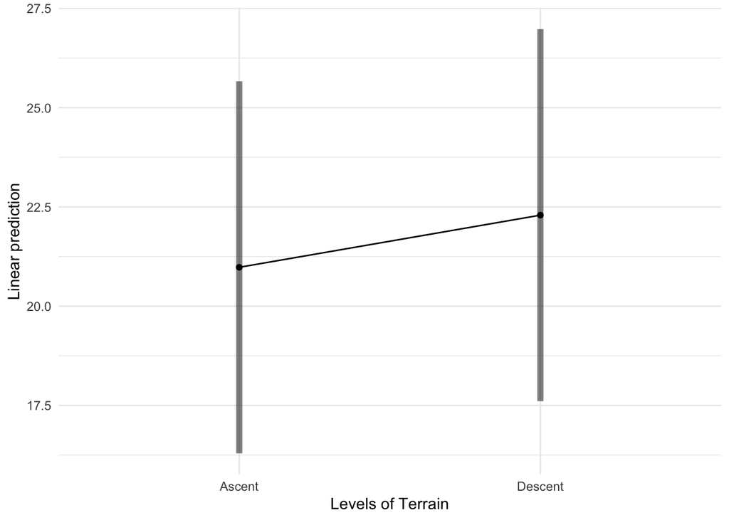

```r
g<-emmip(FinalModel, ~ Terrain, CIs = TRUE)+   theme(axis.text.x = element_text(angle =90))+theme_minimal()
g
```

```r
ggsave(g, file="emmeansAmpTerrModel2.jpeg", height = 6, width=8)
```

The graphical comparisson for MTCs observed in different prosthesis is:

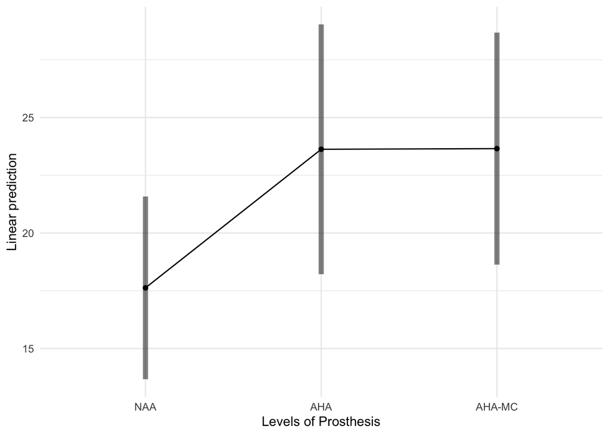

```r
g<-emmip(FinalModel, ~Prosthesis, CIs = TRUE)+
    theme(axis.text.x = element_text(angle = 90))+theme_minimal()
g
```

The Tukey post-hoc test for the Terrain variable is:

```r
pairs(lsmeans(emm, ~ Terrain))
```

```
##  contrast         estimate    SE   df t.ratio p.value
##  Ascent - Descent    -1.31 0.313 1087 -4.195  <.0001
##
## Results are averaged over the levels of: Prosthesis
## Degrees-of-freedom method: containment
```

The average values for MTC in the two terrains here considered are:

```r
lsmeans(emm, ~ Terrain)
```

```
##  Terrain lsmean   SE df lower.CL upper.CL
##  Ascent    21.0 2.15 12     16.3     25.7
##  Descent   22.3 2.15 12     17.6     27.0
##
## Results are averaged over the levels of: Prosthesis
## Degrees-of-freedom method: containment
## Confidence level used: 0.95
```

```r
pairs(lsmeans(emm, ~Prosthesis))
```

```
##  contrast     estimate    SE   df t.ratio p.value
##  NAA - AHA     -6.0005 0.978 1087 -6.133  <.0001
##  NAA - AHA-MC  -6.0297 1.188 1087 -5.073  <.0001
##  AHA - AHA-MC  -0.0293 0.761 1087 -0.038  0.9992
##
## Results are averaged over the levels of: Terrain
## Degrees-of-freedom method: containment
## P value adjustment: tukey method for comparing a family of 3 estimates
```

Thus, on average, the MTC for patients using prosthesis NAA is significantly lower than the MTC measured for both AHA and AHA-MC prostheses.

The average values for MTC corresponding to the contrasts above are:

```r
lsmeans(emm, ~Prosthesis)
```

```
##  Prosthesis lsmean   SE df lower.CL upper.CL
##  NAA          17.6 1.82 12     13.7     21.6
##  AHA          23.6 2.48 12     18.2     29.0
##  AHA-MC       23.7 2.31 12     18.6     28.7
##
## Results are averaged over the levels of: Terrain
## Degrees-of-freedom method: containment
## Confidence level used: 0.95
```